## Reproducible Research

[figure not shown]

Lewis Spurgin

EGI meeting, February 2016

## A reproducibility crisis?

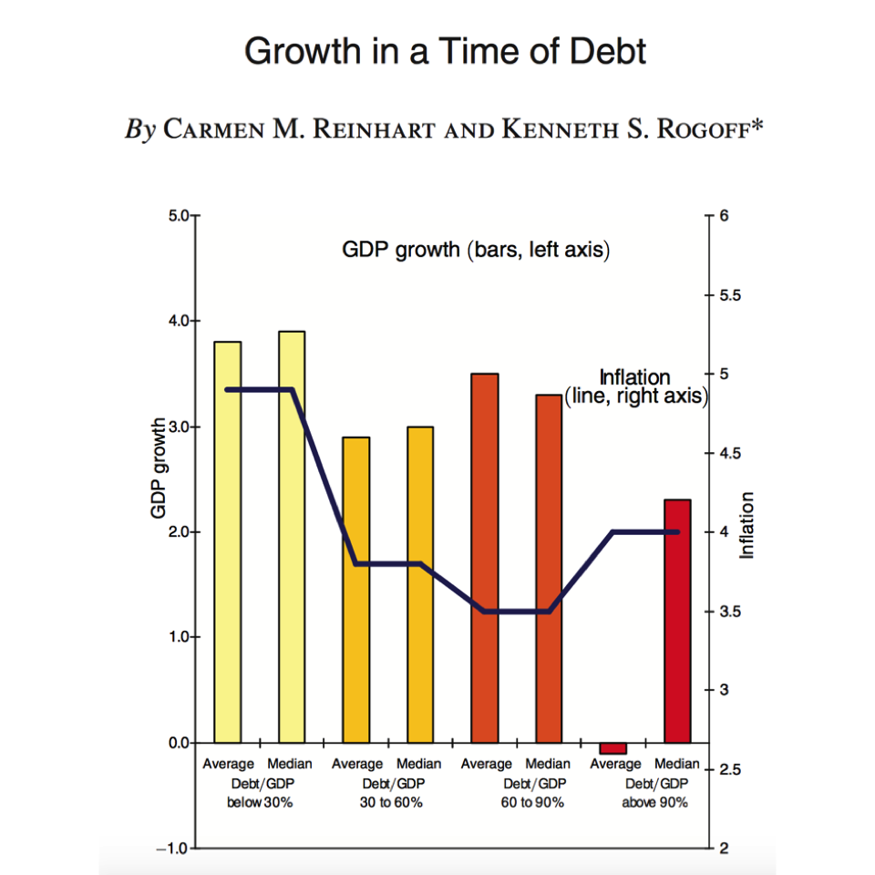

## A reproducibility crisis?

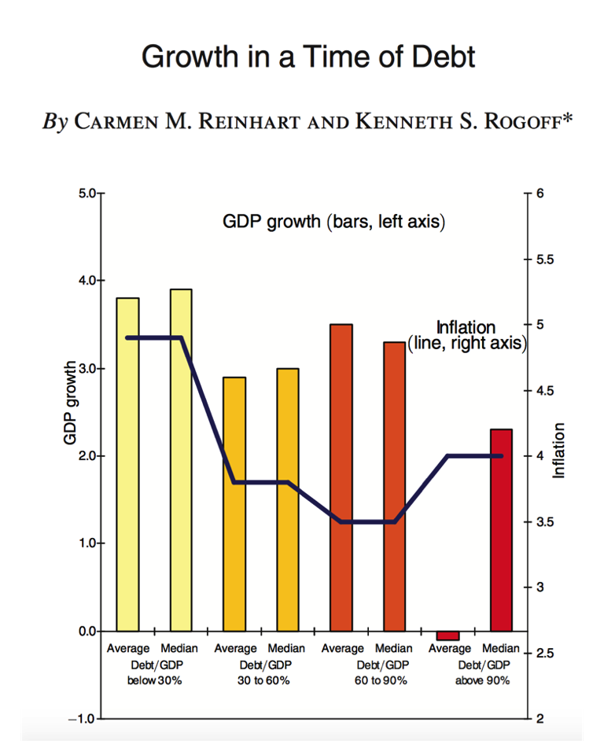

"In their Excel spreadsheet, Reinhart and Rogoff had not selected the entire row when averaging growth figures: they omitted data from Australia, Austria, Belgium, Canada and Denmark… "

## A reproducibility crisis?

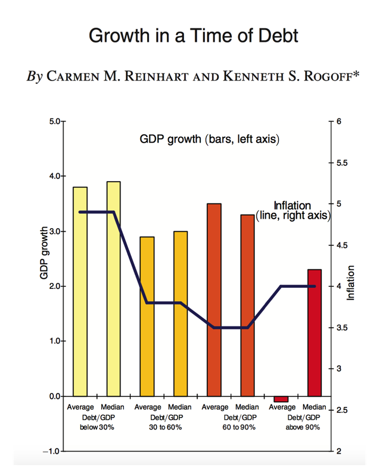

"For an economist, the five most terrifying words in the English language are: I can't replicate your results. But for economists Carmen Reinhart and Ken Rogoff of Harvard, there are seven even more terrifying ones: I think you made an Excel error."

## A reproducibility crisis?

[figure not shown]

## Reproducibility and replicability

- **Replicability** is the ability to replicate results after completely performing an experiment again from scratch.
- **Reproducibility** is the ability to reproduce the same results from a dataset that has already been generated.

## Requirements for reproducible research

- Data are available
- Methods/analyses are transparent

## Data availability

- Now a requirement for many journals and funding agencies
- Gets you more citations
- Long-term storage of data

[figure not shown]

## Data availability

- Usually tidied data uploaded
- What has been done to the raw data?
- Any possibility of errors?

[figure not shown]

## Transparency in methods/analysis

- How were the data formatted?
- How were the data cleaned?
- What exploratory analyses were done?
- How did you create your final analyses/figures?